# Auto-encoding GPS data to reveal individual and collective behaviour

- Show All Code
- Hide All Code
- View Source

Vignette: reproducing the figures of the paper

Author

S. Chabert-Liddell, N. Bez, P. Gloaguen, S. Donnet, S. Mahévas

Published

October 22, 2026

# Introduction

This vignette reproduces the data figures of the paper, in the order in which they appear in the manuscript (`article/main.tex`). Each section states the figure number, the original script it comes from (in `code_vae/R/` or `code_vae/py_workflow/`) and the file name used in `article/figures/`.

The vignette is **plot-only**: it starts from the intermediate results already stored in the repository (latent representations exported by the CVAE/VAE, Bhattacharyya arrays, colSBM fits, bootstrap fits, catch data). The time-consuming steps (training the networks, computing the BC arrays, fitting the colSBM models) are described in Section 5 and are not re-run here.

Figures 1 (architecture of the CVAE) and 2 (workflow) are schematic diagrams and are not produced from data.

## Setup

The vignette must be rendered from the `code_vae/R/` folder (the paths below are relative to it):

```bash
cd code_vae/R
quarto render figures_paper.qmd
```

Packages:

- CRAN: `tidyverse`, `matrixStats`, `patchwork`, `gghighlight`, `maps`, `ggrepel`, `scatterpie`, `cowplot`, `latex2exp`, `mclust`, `gtools`, `reshape2`, `graphclust`.
- GitHub: `colSBM` (`remotes::install_github("GrossSBM/colSBM")`).
- GitLab: `sobolMDA` (https://gitlab.com/drti/sobolmda), a modified version of `ranger` computing the Sobol-MDA importance. Note that the GitLab sources are published under the package name `ranger`: they must be renamed `sobolMDA` before installation, otherwise they overwrite the CRAN `ranger`.

```r
library(tidyverse)
library(lubridate)
library(matrixStats)
library(patchwork)
library(colSBM)
source("./99_helper_functions.R")    # bhattacharyya_1d(), kullback_1d(), coord2std()
source("./98_functions_resampling.R") # get_order(), get_Ztrim*(), ...

theme_set(theme_bw(base_size = 14))
harbour <- c(lon = -4.28, lat = 47.78)

# The three contrasted vessels discussed in the paper
boat <- c(2, 6, 19)
```

## Data

```r
# Latent representations (CVAE d=3, VAE d=4), with dimensions reordered by
# importance (output of 03_computing_bc.R). sig_k are variances (gamma^2).
df_cvae <- read_csv("./Rdata/xgv_cvae_3_reordered_filtered.csv", show_col_types = FALSE)
df_vae  <- read_csv("./Rdata/xgv_vae_4_reordered_filtered.csv",  show_col_types = FALSE)

# Hourly trajectories (output of 02_merge_xgv.R), week days only
df_traj <- read_csv("./Rdata/xgv_100_14-18.csv", show_col_types = FALSE) |>
  filter(wday(time) %in% 2:6, maree != 12097796) |>
  mutate(x_std = coord2std(x, harbour["lon"]),
         y_std = coord2std(y, harbour["lat"]))

# Vessels are numbered 1..33 in the order of appearance in df_cvae
navire_id <- unique(df_cvae$navire)

c(trips = nrow(df_cvae), vessels = length(navire_id))
```

```
  trips vessels
  20511      33
```

# 1 Structure of the latent space

## 1.1 Figure 3 – Choice of the latent dimension

*Original: `py_workflow/comparaison_monitor.ipynb`; file `elbo_dkl.png`.* Loss ($-\mathrm{ELBO}$) and regularisation term ($D_{KL}$) along the 1000 training epochs for the VAE and the CVAE with $d_z = 2, \dots, 5$.

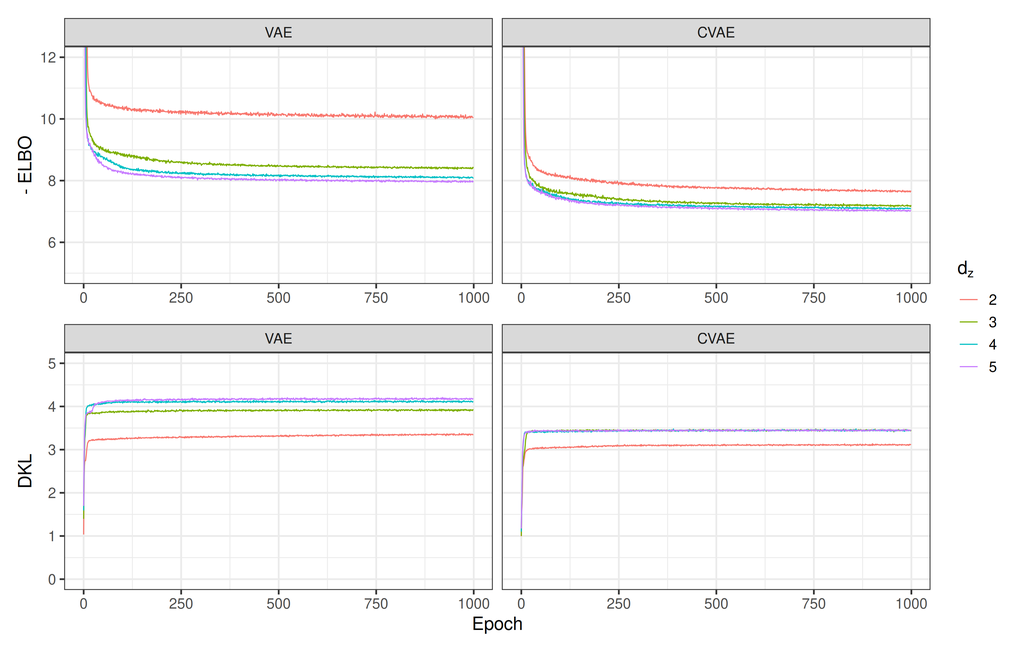

Figure 1: Loss (-ELBO) and regularization term (DKL) for the first 1000 epochs for the VAE and the CVAE with 2 to 5 latent dimensions.

```r
monitor <- expand_grid(model = c("vae", "cvae"), nz = 2:5) |>
  mutate(data = map2(model, nz, \(m, k) read_csv(
    sprintf("../py_workflow/save/monitor_%s_std_10k_%d_adam_1000.csv", m, k),
    show_col_types = FALSE))) |>
  unnest(data) |>
  rename(epoch = `...1`) |>
  mutate(Model = factor(toupper(model), levels = c("VAE", "CVAE")),
         nz = factor(nz))

p_loss <- ggplot(monitor, aes(epoch, loss, col = nz)) +
  geom_line(linewidth = .4) +
  facet_wrap(~ Model) +
  coord_cartesian(ylim = c(5, 12)) +
  labs(x = NULL, y = "- ELBO", col = expression(d[z]))
p_dkl <- ggplot(monitor, aes(epoch, dkl, col = nz)) +
  geom_line(linewidth = .4) +
  facet_wrap(~ Model) +
  coord_cartesian(ylim = c(0, 5)) +
  labs(x = "Epoch", y = "DKL", col = expression(d[z]))
p_loss / p_dkl + plot_layout(guides = "collect")
```

## 1.2 Figure 4 – Ordering the dimensions

*Original: `03_computing_bc.R`; file `plot_dimension.png`.* For $10^5$ random couples of trajectories, distribution of the Bhattacharyya coefficient on each dimension (left), and of the Kullback-Leibler divergence between each variational distribution and the $\mathcal{N}(0,1)$ prior (right). The dimensions are already ordered by importance in the input files.

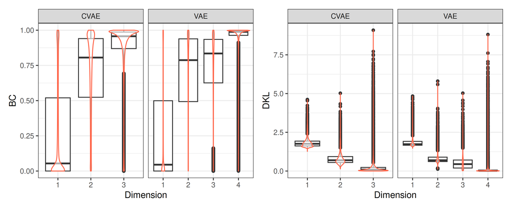

Figure 2: Empirical distribution of BC between couples of variational distribution and Kullback-Leibler divergence between variational distribution and normal Gaussian for each dimension of the latent space.

```r
set.seed(1)
n_traj <- nrow(df_cvae)
ord1 <- sample(n_traj, 2e5, replace = TRUE)
ord2 <- sample(n_traj, 2e5, replace = TRUE)
ind  <- ord1 != ord2
ord1 <- ord1[ind][1:1e5]
ord2 <- ord2[ind][1:1e5]

latent_matrices <- function(df) {
  d <- sum(startsWith(names(df), "mu_"))
  list(mu   = as.matrix(df[paste0("mu_", seq(d))]),
       sig2 = as.matrix(df[paste0("sig_", seq(d))]))
}
lat <- list(CVAE = latent_matrices(df_cvae), VAE = latent_matrices(df_vae))

to_long <- function(m, model, value) {
  colnames(m) <- seq_len(ncol(m))
  as_tibble(m) |>
    pivot_longer(everything(), names_to = "Dim", values_to = value) |>
    mutate(Model = model)
}
df_bc <- imap_dfr(lat, \(l, model) to_long(
  bhattacharyya_1d(l$mu[ord1, ], l$mu[ord2, ], l$sig2[ord1, ], l$sig2[ord2, ]), model, "BC"))
df_kl <- imap_dfr(lat, \(l, model) to_long(kullback_1d(l$mu, 0, l$sig2, 1), model, "DKL"))

plot_dim <- function(df, y) {
  ggplot(df, aes(x = Dim, y = .data[[y]])) +
    geom_boxplot() +
    geom_violin(col = "tomato", alpha = .6) +
    facet_wrap(~ Model, scales = "free_x") +
    xlab("Dimension")
}
plot_dim(df_bc, "BC") + plot_dim(df_kl, "DKL")
```

# 2 Linking latent representations to trajectories

## 2.1 Figure 5 – Time series of the latent distributions

*Original: `04_analysis_selected_vessels.R`; file `plot_ts_mu.png`.* For vessels 2, 6 and 19, time series of $\mu_{(b,t),k}$ and of the band $\mu \pm z\,\gamma$ for the VAE and the CVAE.

**Note**

The script (and hence the published figure) uses $z = $ `qnorm(.95)` $\approx 1.645$, while the caption of the paper states $1.96$. The value used is set below.

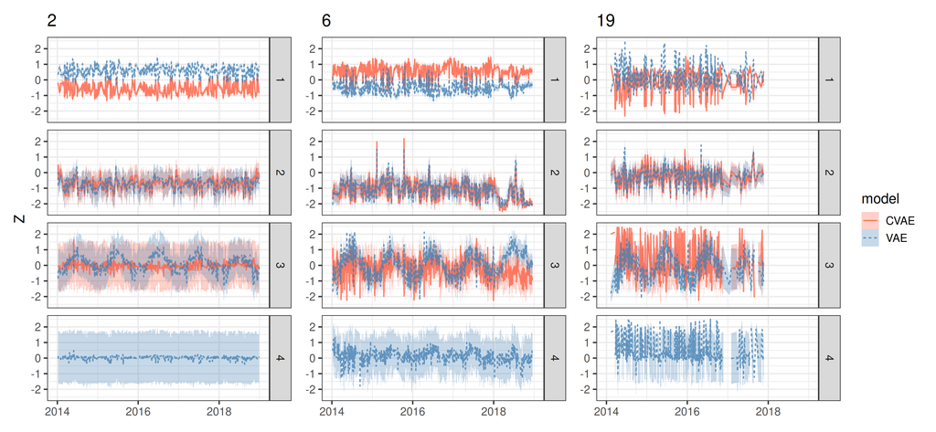

Figure 3: Time series of the latent variational distributions for vessels b = 2, 6, 19 and k = 1, …, d_z.

```r
z_band <- qnorm(.95)

plot_ts <- function(b) {
  bind_rows(VAE = df_vae, CVAE = df_cvae, .id = "model") |>
    filter(navire == navire_id[b]) |>
    pivot_longer(cols = starts_with("mu_") | starts_with("sig_"),
                 names_sep = "_", names_to = c("moment", "dim")) |>
    pivot_wider(names_from = moment, values_from = value) |>
    filter(!is.na(mu)) |>
    ggplot(aes(x = time, y = mu, col = model, fill = model, lty = model)) +
    geom_ribbon(aes(ymin = mu - z_band * sqrt(sig), ymax = mu + z_band * sqrt(sig)),
                linetype = "dotted", alpha = .3, linewidth = .01) +
    geom_line(alpha = .8) +
    scale_color_manual(values = c(CVAE = "tomato", VAE = "steelblue")) +
    scale_fill_manual(values = c(CVAE = "tomato", VAE = "steelblue")) +
    ylim(-2.5, 2.5) +
    xlim(as.Date("2014-01-01"), as.Date("2018-12-31")) +
    facet_grid(dim ~ .) +
    labs(x = NULL, y = NULL, title = b)
}
(plot_ts(2) + ylab("Z")) + plot_ts(6) + plot_ts(19) +
  plot_layout(guides = "collect")
```

## 2.2 Figure 6 – Trajectories and latent space of 3 vessels

*Original: `04_analysis_selected_vessels.R`; file `plot_traj_latent_2-6-19_new.png`.* Highlighted: June 2015 (orange) and December 2015 (blue). In the latent space, $x$, $y$ and point size are $\mu_1$, $\mu_2$ and $\mu_3$.

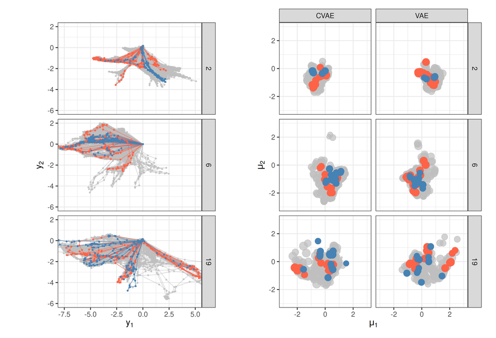

Figure 4: Trajectories and latent space for fishing vessels 2, 6 and 19.

```r
renumber <- function(df) {
  df |>
    filter(navire %in% navire_id[boat]) |>
    mutate(navire = factor(match(navire, navire_id), levels = boat),
           month = factor(month(time), levels = 1:12),
           year = year(time))
}
highlight_months <- c("6", "12")
month_colours <- c(`6` = "tomato", `12` = "steelblue")

p_traj3 <- df_traj |>
  renumber() |>
  ggplot(aes(x = x_std, y = y_std, col = month, group = maree)) +
  geom_path(linewidth = .5, alpha = .5, show.legend = FALSE) +
  geom_point(size = .6, show.legend = FALSE) +
  gghighlight::gghighlight(month %in% highlight_months & year == 2015,
                           calculate_per_facet = TRUE) +
  scale_color_manual(values = month_colours) +
  facet_grid(navire ~ .) +
  coord_fixed(xlim = c(-7.5, 5), ylim = c(-6, 2)) +
  labs(x = expression(y[1]), y = expression(y[2]))

p_lat3 <- bind_rows(VAE = df_vae, CVAE = df_cvae, .id = "Model") |>
  renumber() |>
  ggplot(aes(x = mu_1, y = mu_2, size = mu_3, col = month)) +
  geom_point(show.legend = FALSE) +
  gghighlight::gghighlight(month %in% highlight_months & year == 2015,
                           calculate_per_facet = TRUE) +
  scale_color_manual(values = month_colours) +
  facet_grid(navire ~ Model) +
  coord_fixed(xlim = c(-3, 3), ylim = c(-3, 3)) +
  labs(x = expression(mu[1]), y = expression(mu[2]))

p_traj3 | p_lat3
```

## 2.3 Figure 7 – Trajectories coloured by their latent parameters

*Original: `05a_analysis_latent_space.R`; files `plot_traj_mu.png` and `plot_traj_sig.png`.* Each trajectory is coloured by the mean $\mu_k$ (top) and the variance $\gamma^2_k$ (bottom) of its CVAE variational distribution. The red lozenge is the harbour.

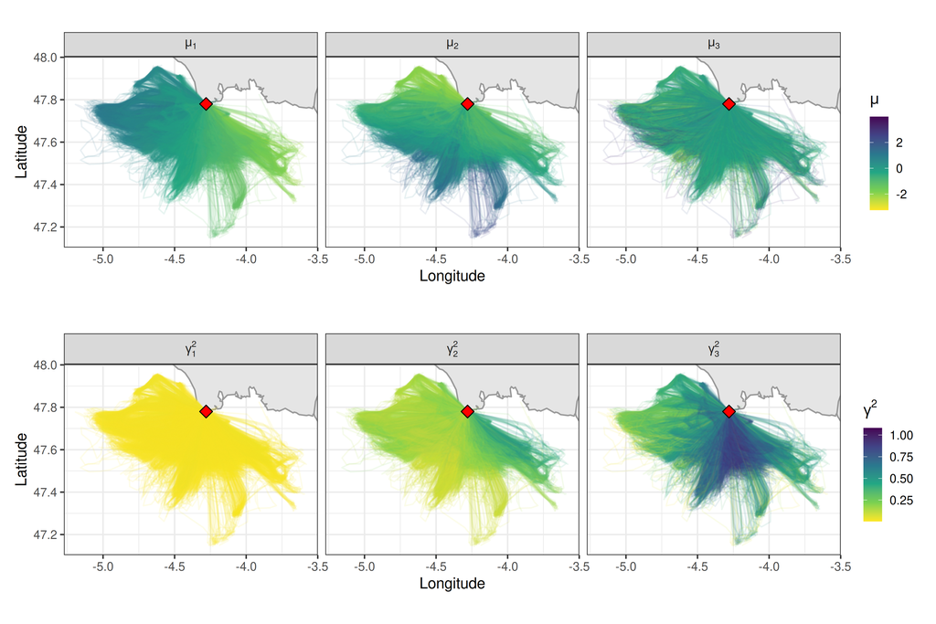

Figure 5: Trajectories coloured by the value of the parameters of their variational distribution in the latent space (mu above and gamma^2 below) on each of the 3 dimensions of the CVAE.

```r
coast <- map_data("france", xlim = c(-5.3, -3.6), ylim = c(47, 48.3))

df_traj_lat <- df_traj |>
  select(maree, x, y) |>
  inner_join(select(df_cvae, maree, starts_with("mu_"), starts_with("sig_")),
             by = "maree")

plot_traj_param <- function(param, labels, legend) {
  df_traj_lat |>
    pivot_longer(cols = starts_with(param), names_to = "Dim", values_to = "value") |>
    mutate(Dim = factor(Dim, levels = paste0(param, 1:3), labels = labels)) |>
    ggplot(aes(x = x, y = y, col = value, group = maree)) +
    annotation_map(coast, fill = "grey90", col = "grey60") +
    geom_path(alpha = .1) +
    annotate("point", x = harbour["lon"], y = harbour["lat"],
             shape = 23, size = 4, fill = "red") +
    scale_colour_viridis_c(direction = -1) +
    facet_wrap(~ Dim, labeller = label_parsed) +
    coord_quickmap() +
    labs(x = "Longitude", y = "Latitude", col = legend)
}
plot_traj_param("mu_", c("mu[1]", "mu[2]", "mu[3]"), expression(mu)) /
  plot_traj_param("sig_", c("gamma[1]^2", "gamma[2]^2", "gamma[3]^2"), expression(gamma^2))
```

## 2.4 Figure 8 – Sensitivity analysis

*Original: `05b_sensitivity_analysis.R`; file `sobol_indices.png`.* Trajectories are generated with the CVAE decoder on a grid of $(z_1, z_2)$ and months ($z_3 = 0$), exported by `py_workflow/cvae_analysis.ipynb` into `generated_traj_cvae3.csv`. For each generated trajectory, the maximal distance to the harbour $D_{\max}$ (km) and the direction of the farthest point $\theta_{\max}$ are predicted from $(z_1, z_2, \cos m, \sin m)$ with a random forest, and the Sobol-MDA index of each input is computed.

**Warning**

The paper reports 10 replications with *independently simulated* trajectory sets (3000 trajectories each). The repository only contains one (deterministic) set of 1200 grid trajectories (960 after `mu1 <= 1.2`). Here the 10 replications differ only by the random seed of the forest, so the min-max bars only reflect the forest variability.

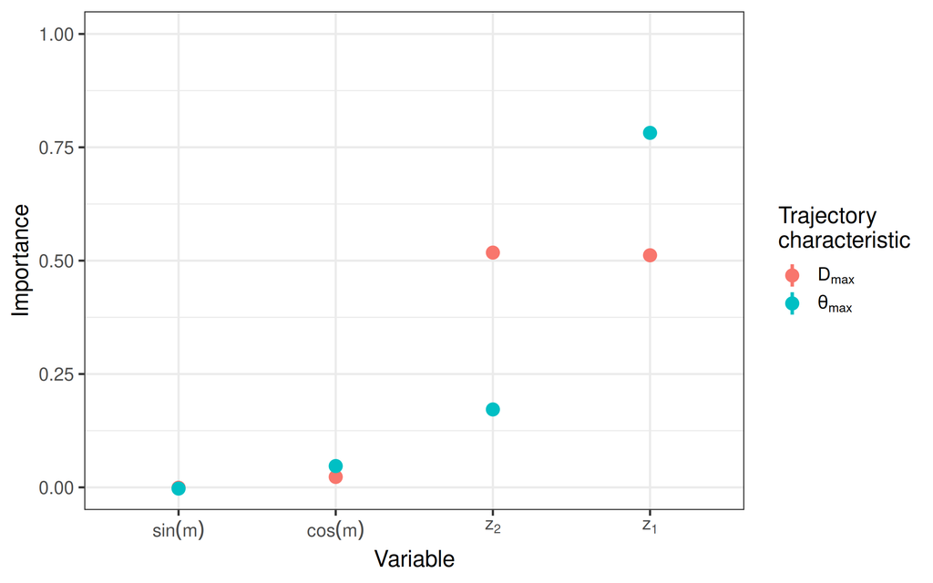

Figure 6: Sensitivity of trajectory characteristics (D_max: distance to the port; theta_max: main direction) to the conditioning variable and the first 2 dimensions. Dots: mean over 10 replications; bars: min-max.

```r
gen <- read.csv("../py_workflow/generated_traj_cvae3.csv", row.names = 1) |>
  filter(mu1 <= 1.2) |>
  mutate(lon = std2coord(x, harbour["lon"]),
         lat = std2coord(y, harbour["lat"])) |>
  # local projection around the harbour (1 minute of arc ~ 1.8 km)
  mutate(x = (lon - harbour["lon"]) * 60 * 1.8 * cos(lat / 180 * pi),
         y = (lat - harbour["lat"]) * 60 * 1.8,
         dist = sqrt(x^2 + y^2),
         theta = atan(y / x)) |>
  group_by(mu1, mu2, cos_eta, sin_eta) |>
  filter(dist == max(dist)) |>
  summarise(max_dist = first(dist), max_theta = first(theta), .groups = "drop")

sobol_importance <- function(response, seed) {
  set.seed(seed)
  fit <- sobolMDA::ranger(reformulate(c("mu1", "mu2", "cos_eta", "sin_eta"), response),
                          data = gen, num.trees = 500, mtry = 3,
                          sample.fraction = 0.1, importance = "sobolMDA")
  enframe(sobolMDA::importance(fit), name = "variable", value = "Importance")
}

importances <- expand_grid(metric = c("max_dist", "max_theta"), rep = 1:10) |>
  mutate(imp = map2(metric, rep, sobol_importance)) |>
  unnest(imp) |>
  group_by(metric, variable) |>
  summarise(mean = mean(Importance), min = min(Importance), max = max(Importance),
            .groups = "drop") |>
  mutate(variable = factor(variable, levels = c("sin_eta", "cos_eta", "mu2", "mu1")))

ggplot(importances, aes(x = variable, y = mean, ymin = min, ymax = max, col = metric)) +
  geom_pointrange(size = .6, linewidth = 1) +
  coord_cartesian(ylim = c(0, 1)) +
  scale_x_discrete(labels = c(mu1 = expression(z[1]), mu2 = expression(z[2]),
                              sin_eta = expression(sin(m)), cos_eta = expression(cos(m)))) +
  scale_color_discrete("Trajectory\ncharacteristic",
                       labels = c(expression(D[max]), expression(theta[max]))) +
  labs(x = "Variable", y = "Importance")
```

# 3 Individual and collective behaviours

## 3.1 Common objects: colSBM groups and stability indices

The groups are given by the colSBM fit on the 20 quarterly proximity graphs (`07b_fit_colsbm_proxy_graphs_replicate_results.R`, saved in `Rdata/save_sbmfit/iidcolsbm_trim_round8.rds`). Groups are relabelled A–F with the ordering functions of `98_functions_resampling.R`, as in `08_analyse_behaviour.R`.

```r
trim_peche <- readRDS("./Rdata/trim_peche.rds")     # vessels active per quarter
bc_lag_cvae_ar <- readRDS("./Rdata/bc_lag_cvae.rds") # BC between adjacent days

iidcolsbm_trim <- readRDS("./Rdata/save_sbmfit/iidcolsbm_trim_round8.rds")$best_fit
Q <- iidcolsbm_trim$nb_clusters

best_ord   <- get_order(iidcolsbm_trim)
Z_trim     <- get_Ztrim_relabel(iidcolsbm_trim) |> relabel_Ztrim(best_ord) # 33 x 20
Z_trim_map <- get_Ztrim_map(Z_trim)

# Proportion of the quarters spent by each vessel in each group
Mat_navire <- outer(Z_trim, seq(Q), "==") |>
  apply(c(1, 3), mean, na.rm = TRUE) |>
  `colnames<-`(LETTERS[1:Q]) |>
  as_tibble() |>
  mutate(navire = seq(33), .before = 1)

group_colours <- setNames(scales::hue_pal()(Q), LETTERS[1:Q])
Q
```

```
[1] 6
```

The daily stability index (DSI, proportion of couples of trajectories on adjacent days with $\mathrm{BC} \geq 0.8$) and the global stability index (GSI, same for random couples of trajectories of the vessel) are computed as in `08_analyse_behaviour.R`.

```r
threshold <- 0.8

# Vessel x day array of variational parameters (missing trips are NA)
df_cvae_c <- tibble(time = rep(seq(min(df_cvae$time), max(df_cvae$time), by = "days"), times = 33),
                    navire = rep(navire_id, each = length(time) / 33)) |>
  filter(wday(time) %in% 2:6) |>
  full_join(df_cvae, by = c("time", "navire")) |>
  arrange(time)

ar_cvae_c <- df_cvae_c |>
  select(starts_with("mu") | starts_with("sig")) |>
  t() |> as.vector() |>
  array(dim = c(6, 33, nrow(df_cvae_c) / 33)) |>
  aperm(c(1, 3, 2))
ar_cvae_mu   <- ar_cvae_c[1:3, , ]
ar_cvae_sig2 <- ar_cvae_c[4:6, , ]
n_days <- dim(ar_cvae_mu)[2]

# DSI: BC between the trajectories of a vessel on two consecutive fishing days
bclag_navire <- bhattacharyya_1d(
  mu1  = ar_cvae_mu[, -n_days, ],   mu2  = ar_cvae_mu[, -1, ],
  var1 = ar_cvae_sig2[, -n_days, ], var2 = ar_cvae_sig2[, -1, ]) |>
  apply(c(2, 3), prod)

# GSI: BC between 2e4 random couples of trajectories of the vessel
mu_cvae   <- as.matrix(select(df_cvae, starts_with("mu")))
sig2_cvae <- as.matrix(select(df_cvae, starts_with("sig")))
set.seed(2)
bc_navire <- sapply(seq(33), function(b) {
  ind  <- which(df_cvae$navire == navire_id[b])
  ord1 <- sample(ind, 3e4, replace = TRUE)
  ord2 <- sample(ind, 3e4, replace = TRUE)
  keep <- which(ord1 != ord2)[1:2e4]
  rowProds(bhattacharyya_1d(mu_cvae[ord1[keep], ], mu_cvae[ord2[keep], ],
                            sig2_cvae[ord1[keep], ], sig2_cvae[ord2[keep], ]))
})

bc_seuil_navire <- tibble(navire = seq(33),
                          lag  = colMeans(bclag_navire >= threshold, na.rm = TRUE),
                          dist = colMeans(bc_navire >= threshold, na.rm = TRUE)) |>
  left_join(Mat_navire, by = "navire")

# Fleet level indices (all couples of vessels)
set.seed(3)
ord1 <- sample(nrow(df_cvae), 2e5, replace = TRUE)
ord2 <- sample(nrow(df_cvae), 2e5, replace = TRUE)
keep <- which(ord1 != ord2)[1:1e5]
fleet <- tibble(
  lag  = mean(bc_lag_cvae_ar > threshold, na.rm = TRUE),
  dist = mean(rowProds(bhattacharyya_1d(mu_cvae[ord1[keep], ], mu_cvae[ord2[keep], ],
                                        sig2_cvae[ord1[keep], ], sig2_cvae[ord2[keep], ])) > threshold))

# Average of the individual indices, overall and per group (weighted by membership)
mean_boat  <- summarise(bc_seuil_navire, lag = mean(lag), dist = mean(dist))
mean_group <- bc_seuil_navire |>
  pivot_longer(all_of(LETTERS[1:Q]), names_to = "Group", values_to = "Prop") |>
  group_by(Group) |>
  summarise(lag = weighted.mean(lag, Prop), dist = weighted.mean(dist, Prop))

knitr::kable(bind_rows(Fleet = fleet, `Mean of vessels` = mean_boat, .id = "Level") |>
               bind_rows(rename(mean_group, Level = Group)),
             digits = 3, col.names = c("Level", "DSI", "GSI"))
```

| Level | DSI | GSI |
| --- | --- | --- |
| Fleet | 0.159 | 0.043 |
| Mean of vessels | 0.444 | 0.079 |
| A | 0.393 | 0.051 |
| B | 0.459 | 0.056 |
| C | 0.459 | 0.085 |
| D | 0.470 | 0.112 |
| E | 0.396 | 0.078 |
| F | 0.368 | 0.060 |

## 3.2 Figure 9 – Individual stabilities

*Original: `08_analyse_behaviour.R`; file `bc_group_colsbm_trim_cvae.png`.* Pies: proportions of group memberships of each vessel; squares: group averages; triangle: average of the vessels; diamond: fleet.

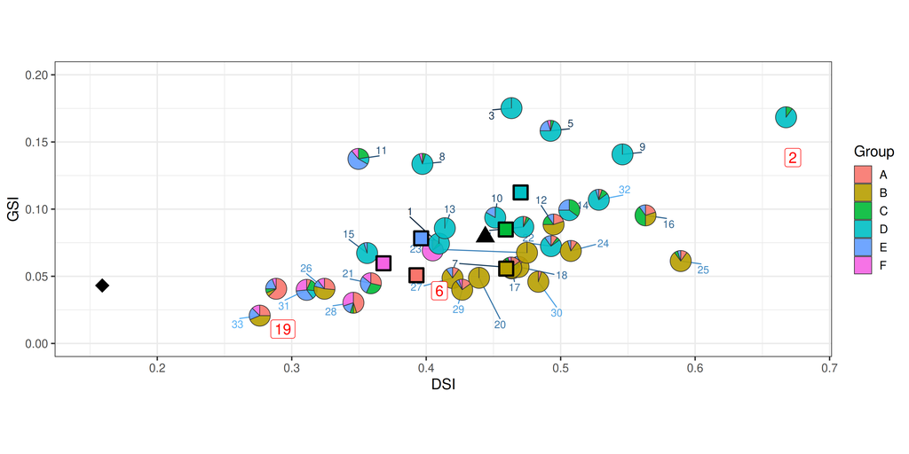

Figure 7: Proportions of trajectories with high overlap between their latent representations (BC >= 0.8) for the 33 fishing vessels: daily (DSI, x-axis) and global (GSI, y-axis) stability.

```r
ggplot(bc_seuil_navire) +
  ggrepel::geom_text_repel(data = filter(bc_seuil_navire, !navire %in% boat),
                           aes(x = lag, y = dist, col = navire, label = navire),
                           show.legend = FALSE, size = 3.5, max.overlaps = 20,
                           force = 5, force_pull = 5, box.padding = 1) +
  scatterpie::geom_scatterpie(aes(x = lag, y = dist), data = bc_seuil_navire,
                              cols = LETTERS[1:Q], pie_scale = 1, alpha = .9,
                              color = "grey20", linewidth = .3, legend_name = "Group") +
  ggrepel::geom_label_repel(data = filter(bc_seuil_navire, navire %in% boat),
                            aes(x = lag, y = dist, label = navire),
                            size = 5, col = "red", min.segment.length = 0.1,
                            direction = "y", nudge_y = -0.03, nudge_x = .005,
                            point.padding = 4, show.legend = FALSE) +
  geom_point(data = mean_group, aes(x = lag, y = dist, fill = Group),
             size = 6, shape = 22, stroke = 1.5, show.legend = FALSE) +
  geom_point(data = mean_boat, aes(x = lag, y = dist), size = 6, shape = 17) +
  geom_point(data = fleet, aes(x = lag, y = dist), size = 6, shape = 18) +
  scale_fill_manual(values = group_colours) +
  coord_equal(xlim = c(0.15, NA), ylim = c(0, 0.2)) +
  labs(x = "DSI", y = "GSI")
```

## 3.3 Figure 10 – Mesoscale structure and group memberships

*Original: `08_analyse_behaviour.R`; file `iidcolsbm_group_trim.png`.* Left: common connectivity structure of the 20 quarterly proximity graphs (block widths are the group proportions). Right: proportion of the quarters each vessel spends in each group; vessels 2, 6 and 19 are framed in red.

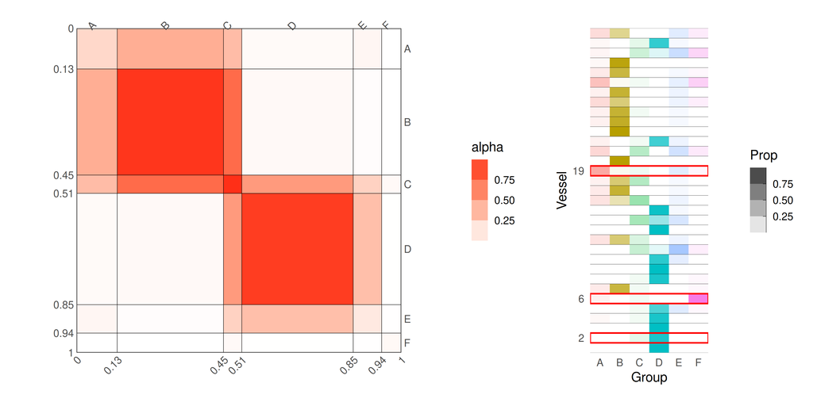

Figure 8: Left: common mesoscale structure of the collection (6 groups A to F). Right: proportions of group membership for each fishing vessel across the 20 quarterly proximity graphs.

```r
p_meso <- plot(iidcolsbm_trim, type = "graphon", ord = best_ord)
breaks1 <- c(0, cumsum(iidcolsbm_trim$pi[[1]][best_ord])) # block boundaries
breaks2 <- (breaks1[-1] + breaks1[-(Q + 1)]) / 2
p_meso <- p_meso +
  scale_y_continuous(breaks = breaks1, labels = round(breaks1, 2), transform = "reverse",
                     sec.axis = sec_axis(transform = identity, breaks = breaks2,
                                         labels = LETTERS[1:Q])) +
  scale_x_continuous(breaks = breaks1, labels = round(breaks1, 2),
                     sec.axis = sec_axis(transform = identity, breaks = breaks2,
                                         labels = LETTERS[1:Q])) +
  guides(fill = guide_colorsteps()) +
  labs(x = NULL, y = NULL) +
  theme_bw(base_size = 14) +
  theme(axis.ticks = element_blank(),
        axis.text.x = element_text(angle = 45, hjust = 1))

Mat_groups <- Mat_navire |>
  pivot_longer(-navire, names_to = "Group", values_to = "Prop")
frame <- tibble(y = boat)

p_groups <- ggplot(Mat_groups, aes(x = Group, y = navire, alpha = Prop, fill = Group)) +
  geom_tile() +
  geom_hline(yintercept = seq(0, 33) + .5, linewidth = .1) +
  geom_rect(data = frame, inherit.aes = FALSE,
            aes(xmin = .5, xmax = Q + .5, ymin = y - .5, ymax = y + .5),
            fill = NA, col = "red", linewidth = .8) +
  scale_fill_manual(values = group_colours, guide = "none") +
  scale_alpha_continuous(range = c(0, 1), guide = guide_bins(reverse = TRUE)) +
  scale_y_continuous(breaks = boat) +
  coord_fixed(ratio = 1 / 2, expand = FALSE) +
  labs(y = "Vessel") +
  theme_minimal(base_size = 14, base_line_size = 0)

p_meso + p_groups + plot_layout(widths = c(3, 1.2))
```

## 3.4 Figure 11 – Trajectories, latent space and income per group

*Original: `10_analyze_group.R`; files `latent_space_group.png` and `income_per_trip_noguide.png`.* Each trip is assigned the group of its vessel during the corresponding quarter.

```r
df_cvae_group <- df_cvae |>
  mutate(quarteryear = quarter(time) + 4 * (year(time) - 2014),
         b = match(navire, navire_id),
         Group = factor(LETTERS[Z_trim[cbind(b, quarteryear)]], levels = LETTERS[1:Q]),
         quarter = factor(quarter(time)))
dplyr::count(df_cvae_group, Group)
```

```
# A tibble: 6 × 2
  Group     n
  <fct> <int>
1 A      1834
2 B      6661
3 C      1678
4 D      7993
5 E      1285
6 F      1060
```

### 3.4.1 (a) Trajectories and latent space per group

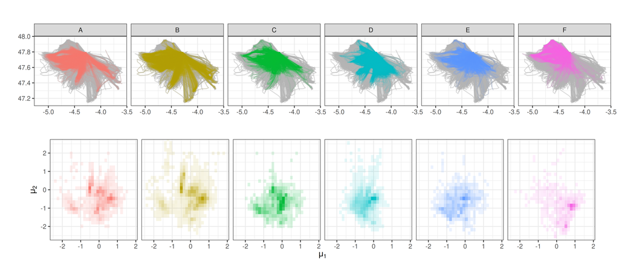

Figure 9: Top: trajectories by colSBM group (all trajectories in grey). Bottom: distribution of (mu_1, mu_2) for the same trajectories.

```r
df_traj_group <- df_traj |>
  select(maree, x, y) |>
  inner_join(select(df_cvae_group, maree, Group), by = "maree") |>
  filter(!is.na(Group))

p_traj_group <- ggplot(df_traj_group, aes(x = x, y = y, col = Group, group = maree)) +
  geom_path(data = select(df_traj_group, -Group), aes(x = x, y = y, group = maree),
            inherit.aes = FALSE, col = "gray70", alpha = .5) +
  geom_path(alpha = .1, show.legend = FALSE) +
  scale_colour_manual(values = group_colours) +
  facet_wrap(~ Group, nrow = 1) +
  coord_quickmap() +
  labs(x = NULL, y = NULL)

p_lat_group <- df_cvae_group |>
  filter(!is.na(Group)) |>
  ggplot(aes(x = mu_1, y = mu_2, fill = Group)) +
  stat_bin_2d(aes(alpha = after_stat(ndensity)), bins = 30, show.legend = FALSE) +
  scale_fill_manual(values = group_colours) +
  facet_wrap(~ Group, nrow = 1) +
  coord_fixed(ylim = c(-2.5, 2.5)) +
  labs(x = expression(mu[1]), y = expression(mu[2])) +
  theme(strip.background = element_blank(), strip.text = element_blank())

p_traj_group / p_lat_group
```

### 3.4.2 (b) Income per trip

Gross value per fishing trip (sum over the landed species; catch lines above 10 000 € are removed as in the original script), summarised by quarter and group: black line = median, shades = $[\xi, 1-\xi]$ quantiles for $\xi \in \{.10, .25\}$, dotted lines = 1% and 99% quantiles.

```r
income <- read_csv("./Rdata/sacrois_xgv_capt.csv", show_col_types = FALSE) |>
  filter(MONTANT_EUROS_MOYENNE <= 10000) |>
  rename(maree = MAREE_ID) |>
  inner_join(select(df_cvae_group, maree, time, Group), by = "maree") |>
  mutate(date = as_date(paste(year(time), 3 * quarter(time), "01", sep = "-"))) |>
  group_by(maree, Group, date) |>
  summarise(income = sum(MONTANT_EUROS_MOYENNE, na.rm = TRUE) / 1000, .groups = "drop")

income |>
  group_by(Group) |>
  summarise(`mean income per trip (k€)` = mean(income), trips = n()) |>
  knitr::kable(digits = 2)
```

| Group | mean income per trip (k€) | trips |
| --- | --- | --- |
| A | 2.26 | 1834 |
| B | 2.38 | 6661 |
| C | 1.82 | 1677 |
| D | 1.40 | 7962 |
| E | 1.71 | 1282 |
| F | 1.81 | 1060 |

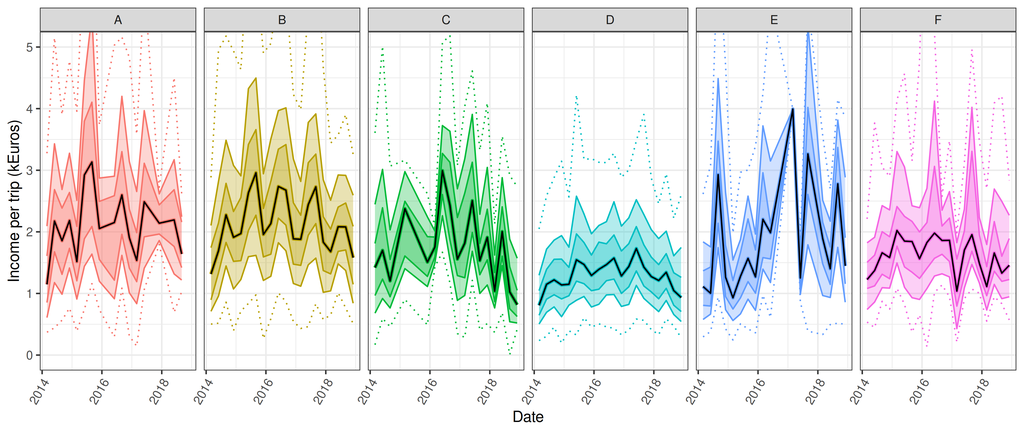

Figure 11: Quantile distribution of the income (gross values) per fishing trip by quarter and by the group found with the colSBM model.

```r
probs <- c(.01, .10, .25, .50, .75, .90, .99)
income_q <- income |>
  group_by(Group, date) |>
  reframe(q = probs, value = quantile(income, probs)) |>
  pivot_wider(names_from = q, values_from = value, names_prefix = "q")

ggplot(income_q, aes(x = date, col = Group, fill = Group)) +
  geom_ribbon(aes(ymin = q0.1, ymax = q0.9), alpha = .3) +
  geom_ribbon(aes(ymin = q0.25, ymax = q0.75), alpha = .3) +
  geom_line(aes(y = q0.01), linetype = 3) +
  geom_line(aes(y = q0.99), linetype = 3) +
  geom_line(aes(y = q0.5), linewidth = 1.5) +
  geom_line(aes(y = q0.5), col = "black") +
  scale_colour_manual(values = group_colours, aesthetics = c("colour", "fill")) +
  facet_wrap(~ Group, nrow = 1) +
  coord_cartesian(ylim = c(0, 5)) +
  labs(x = "Date", y = "Income per trip (kEuros)") +
  theme(legend.position = "none",
        axis.text.x = element_text(angle = 60, hjust = 1))
```

# 4 Appendix figures

## 4.1 Figure A1 – Reconstruction of trajectories

*Original: `py_workflow/cvae_analysis.ipynb`; file `cvae_trajrec_nz3_48.png`.* 48 random real trajectories (red) and their reconstruction $G(\hat\mu_m, c_m; \hat\theta)$ by the CVAE with $d_z = 3$ (blue). This is the only figure that needs the trained network: run first, from `py_workflow/` (requires `torch`, `pandas`, `numpy`)

```bash
python export_reconstruction.py --nz 3 --n 48
```

which writes `R/pydata/reconstruction_cvae3.csv`.

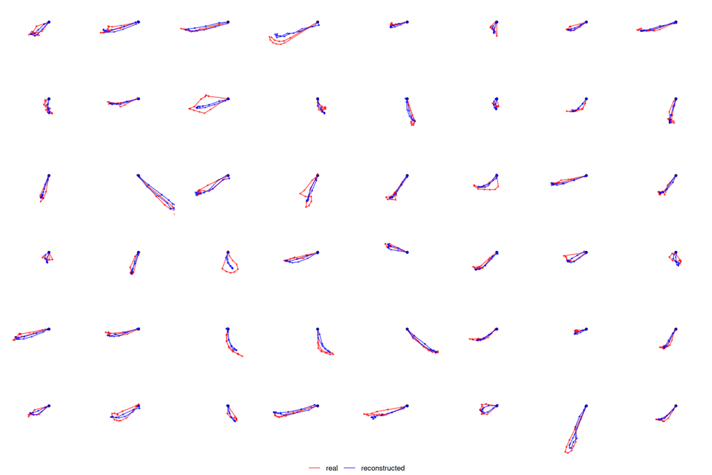

Figure 12: Sample of 48 real trajectories (red) drawn uniformly at random and their reconstruction (blue) by the CVAE with 3 latent dimensions.

```r
rec_file <- "./pydata/reconstruction_cvae3.csv"
if (file.exists(rec_file)) {
  read_csv(rec_file, show_col_types = FALSE) |>
    ggplot(aes(x = x, y = y, col = type, group = type)) +
    annotate("point", x = 0, y = 0, size = 1) +
    geom_path(alpha = .6) +
    geom_point(aes(alpha = h), size = .5, show.legend = FALSE) +
    scale_alpha(range = c(.6, .1)) +
    scale_colour_manual(NULL, values = c(real = "red", reconstructed = "blue")) +
    facet_wrap(~ id, nrow = 6) +
    coord_cartesian(xlim = c(-7, 5), ylim = c(-5, 2)) +
    theme_void() +
    theme(strip.text = element_blank(), legend.position = "bottom",
          panel.border = element_rect(fill = NA, colour = "grey60"))
} else {
  message("Run py_workflow/export_reconstruction.py first to produce ", rec_file)
}
```

## 4.2 Figure A2 – Quarterly proximity graphs

*Original: `08_analyse_behaviour.R`; file `proxy_graph_trim.png`.* Adjacency matrices of the 20 quarterly proximity graphs (rows: quarters, columns: years). Vessels not active during a quarter are `NA` (pink).

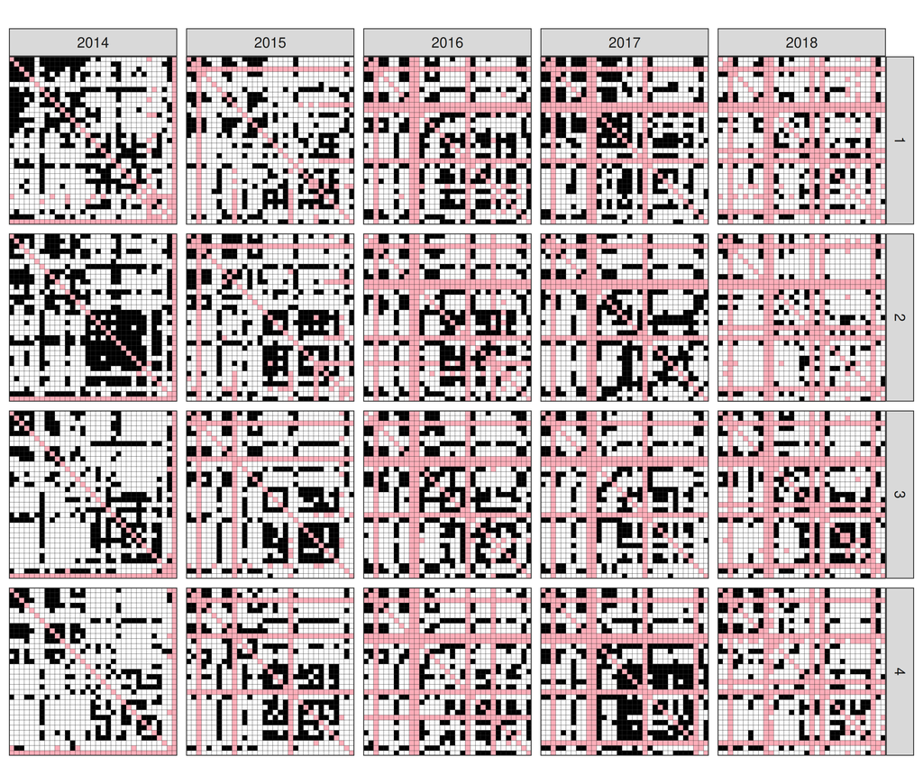

Figure 13: Adjacency matrices of the 20 quarterly proximity graphs between fishing vessels. Proximity between vessels is printed in black and NA value in pink.

```r
trim_matrices <- lapply(seq(20), function(l) {
  A <- matrix(NA, 33, 33)
  A[trim_peche[[l]], trim_peche[[l]]] <- iidcolsbm_trim$A[[l]]
  A[A == -1] <- NA
  diag(A) <- NA
  A
})

array(unlist(trim_matrices), dim = c(33, 33, 20)) |>
  reshape2::melt() |>
  mutate(Quarter = (Var3 - 1) %% 4 + 1,
         Year = 2014 + (Var3 - 1) %/% 4) |>
  ggplot(aes(x = Var1, y = Var2, fill = value)) +
  geom_tile(show.legend = FALSE) +
  scale_y_reverse() +
  scale_fill_gradient(low = "white", high = "black", limits = c(0, 1), na.value = "lightpink1") +
  geom_hline(yintercept = seq(0, 33) + .5, linewidth = .1, color = "grey20") +
  geom_vline(xintercept = seq(0, 33) + .5, linewidth = .1, color = "grey20") +
  coord_fixed(expand = FALSE) +
  facet_grid(Quarter ~ Year) +
  labs(x = NULL, y = NULL) +
  theme(axis.text = element_blank(), axis.ticks = element_blank())
```

## 4.3 Figure A3 – Bootstrap

*Original: `07c_fit_colsbm_proxy_graphs_resampling.R`; file `images2/bootstrap_results_90.png`.* colSBM fitted on 30 collections of networks built from 90% of the days of each quarter (fits saved in `Rdata/save_colsbm_bootstrap/fits_90/`). Top: mesoscale structure of one bootstrap sample per value of $\hat K$, with groups aligned on the full-data fit by minimising the $L_2$ distance between graphons. Bottom: ARI between the bootstrap and the full-data clusterings, for each sample and each quarter.

**Important**

The bootstrap fits of the first version of the paper (now in `archive/Rdata/save_colsbmfit_subsample/res_iidcolsbm_subnets_90/`, fits 1 to 30) were all estimated on the same network collection (see the header of `07c_fit_colsbm_proxy_graphs_resampling.R`). The fits used here were recomputed with the corrected script, one distinct sub-sample per replicate.

```r
N_sub <- 30
boot_fits <- lapply(seq(N_sub), function(k) readRDS(sprintf(
  "./Rdata/save_colsbm_bootstrap/fits_90/iidcolsbm_trim_sub_net_%d.rds", k))$best_fit)

K_hat <- sapply(boot_fits, \(f) f$nb_clusters)
round(100 * prop.table(table(K_hat)))
```

```
K_hat
 5  6
10 90
```

```r
# replicates shown in the paper: one with K_hat = 6, one with K_hat = 5
m_show <- c(3, 4)

Z_full <- get_Ztrim(iidcolsbm_trim)
ARI <- sapply(boot_fits, function(f) {
  Z_k <- get_Ztrim(f)
  sapply(1:20, function(t) {
    keep <- !is.na(Z_k[, t]) & !is.na(Z_full[, t])
    mclust::adjustedRandIndex(Z_full[keep, t], Z_k[keep, t])
  })
})
summary(c(ARI))
```

```
   Min. 1st Qu.  Median    Mean 3rd Qu.    Max.
 0.3134  0.6848  0.7716  0.7622  0.8623  1.0000
```

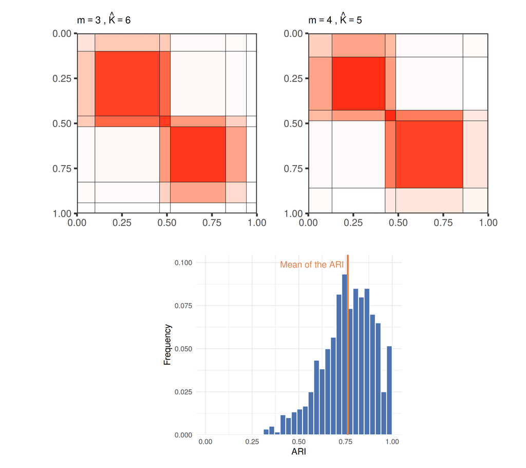

Figure 14: Top: estimated mesoscale structures obtained from one bootstrap sample per selected number of blocks K. Bottom: histogram of the adjusted Rand index (ARI) between bootstrap and full-data clusterings.

```r
plot_boot <- function(m) {
  f <- boot_fits[[m]]
  o <- get_order_withref(f, iidcolsbm_trim, best_ord)
  plot(f, type = "graphon", ord = o) +
    ggtitle(bquote(m == .(m) ~ "," ~ hat(K) == .(f$nb_clusters))) +
    theme(legend.position = "none", plot.title = element_text(size = 12))
}

p_hist_ARI <- ggplot(tibble(ARI = c(ARI)), aes(x = ARI)) +
  # boundary = 1: the last bin ends at 1, so that ARI = 1 is not dropped
  geom_histogram(aes(y = after_stat(count / sum(count))), binwidth = 0.03,
                 boundary = 1, fill = "#4C72B0", color = "white") +
  geom_vline(xintercept = mean(ARI, na.rm = TRUE), color = "#DD8452", linewidth = 1.1) +
  annotate("text", x = mean(ARI, na.rm = TRUE) - 0.02, y = Inf, hjust = 1,
           vjust = 2, label = "Mean of the ARI", color = "#DD8452") +
  coord_cartesian(xlim = c(0, 1)) +
  scale_y_continuous(expand = expansion(mult = c(0, 0.12))) + # room for the label
  ylab("Frequency") +
  theme_minimal()

wrap_plots(lapply(m_show, plot_boot), nrow = 1) /
  (plot_spacer() + p_hist_ARI + plot_spacer() + plot_layout(widths = c(1, 2, 1)))
```

# 5 From raw data to the inputs of this vignette

The intermediate files read above are produced by the following steps (raw SACROIS / SIH-GEOLOC data are confidential and not in the repository).

| Step | Script | Output |
| --- | --- | --- |
| Extract and align hourly trajectories | `01_extract_xgv.R`, `02_merge_xgv.R` | `Rdata/xgv_100_14-18.csv` |
| Train the VAE / CVAE ($d_z = 2..5$) | `py_workflow/train_traj_vae.py` | `py_workflow/save/*.pth`, `monitor_*.csv` |
| Export latent representations, generate grid trajectories | `py_workflow/cvae_analysis.ipynb` | `pydata/latentspace_*.csv`, `generated_traj_cvae3.csv` |
| Order the dimensions | `03_computing_bc.R` | `Rdata/xgv_{cvae_3,vae_4}_reordered_filtered.csv` |
| BC between vessels, same / adjacent days | `06_build_proximity_graph.R` | `Rdata/bc_jour_cvae.rds`, `bc_lag_cvae.rds`, `ldates.rds` |
| Quarterly graphs and colSBM fit | `07b_fit_colsbm_proxy_graphs_replicate_results.R` | `Rdata/trim_peche.rds`, `Rdata/save_sbmfit/iidcolsbm_trim_round8.rds` |
| Bootstrap of the colSBM | `07c_fit_colsbm_proxy_graphs_resampling.R` | `Rdata/save_colsbm_bootstrap/` |
| Catch data of the trips | `09_extract_xgv_capture.R` | `Rdata/sacrois_xgv_capt.csv` |
| Reconstructions for Figure A1 | `py_workflow/export_reconstruction.py` | `pydata/reconstruction_cvae3.csv` |